# Model selection in GLMs

Joe Parker

9th November 2018

# Root and leaf microbiomes

The data in this practical are taken from Wagner *et al.* (2016; `doi:0.1038/ncomms12151`). This is an in-depth comparison of the root and leave microbiomes (microbial community composition) in experimental populations of the wild mustard plant, *Boechera stricta* (Brassicaceae), investigated using metagenomic DNA sequencing. The plants were planted out carefully-designed plots under controlled conditions, and some individuals from each plot were removed each year, their roots and leaves harvested, and microbial DNA extracted and sequenced. The bioinformatics packages `QIIME` and `Phyloseq` were used to process the data, and statistical analysis was performed using `R` - just as you’re about to do…

## Experimental design

The experimental design is given below:

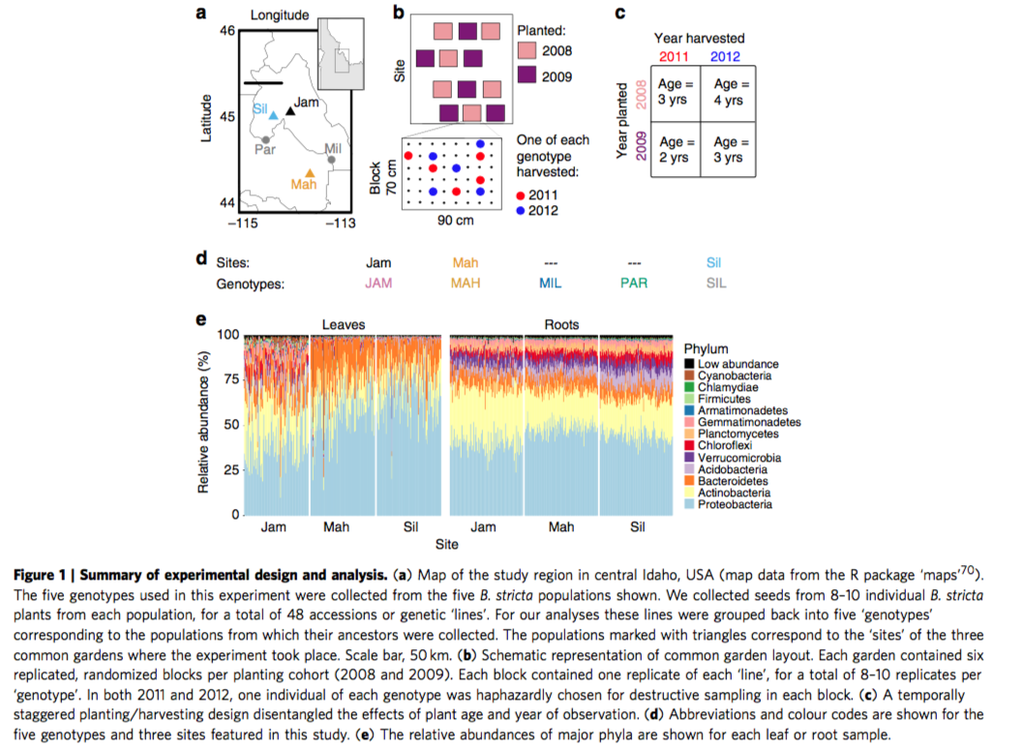

*And also from the Results*:

[output not shown]

Questions:

1. Which factors are blocks, and which are treatments?
2. How many levels are there in this experiment?
3. How many replicates? Are there any pseudoreplicates? Why?
4. Is this design orthogonal? If not, why not?
5. Is there anything else worth noting about the design?

## Model selection and fitting by heuristics

The data for this paper is held in Dryad, a large open-access repository of research paper data and analyses. If you want to explore it yourself, head to http://datadryad.org/resource/doi:10.5061/dryad.g60r3; I’ve simplified the data slightly for this practical.

1. Open the file `wagner_2016_microbiome.tdf` by reading it into `R`. Inspect the data frame and verify that variables have imported correctly (categorical variables as factors, etc - *Hint, you may need to clean your data, or use the* `as.factor()` or `as.numeric()`*conversion functions*).

```r
wagner = read.table("R_code_Wagner_etal_2016/wagner_2016_microbiome.tdf",header=T,sep="\t")
wagner$planting = as.factor(wagner$plant_year)
wagner$sampling = as.factor(wagner$sample_year)
wagner$miseq_run = as.factor(wagner$miseq)
attach(wagner)
```

We are seeking to explain microbial diversity (measured by two variables, `CHAO1` and `Shannon`) using the available factors. To start with, let’s try and fit a few models using the available parameters. There are a lot of variables here, so rather than eyeball each one separately, we can call `plot()` on the data.frame to produce simple pairwise scatterplots for all variables:

```r
plot(wagner)
```

2. There are actually two response variables in this dataset, which represent alternative measures of microbial diversity: `CHAO1` and `Shannon`. Which should we use, we wonder? Surely they should be highly correlated if both measure the same thing - but is there anything weird here? Try plotting them, and fitting a model (*BIG hint: check your assumptions!*)

```r
plot(CHAO1,Shannon)
response_model=lm(Shannon~CHAO1)
anova(response_model)
```

```
Analysis of Variance Table

Response: Shannon
           Df Sum Sq Mean Sq F value    Pr(>F)
CHAO1       1 670.99  670.99  2971.4 < 2.2e-16 ***
Residuals 754 170.27    0.23
---
Signif. codes:
0 *** 0.001 ** 0.01 * 0.05 . 0.1   1
```

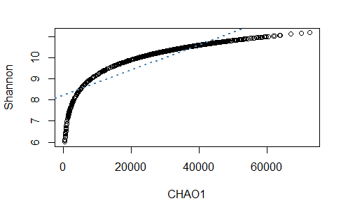

```r
abline(response_model,col="steelblue",lwd=2,lty=3)
```

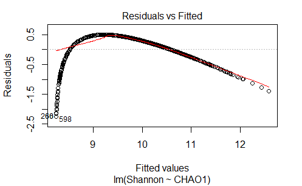

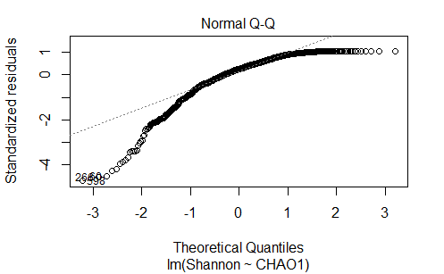

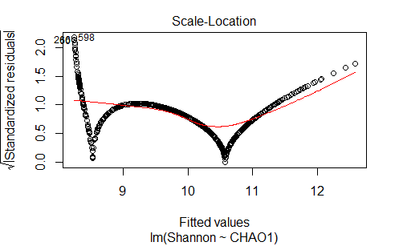

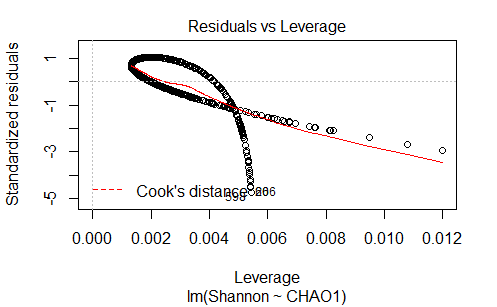

```r
plot(response_model)
```

What do you conclude? Try plotting each response variable as a histogram before you decide which to use as the response variable for the rest of the analysis.

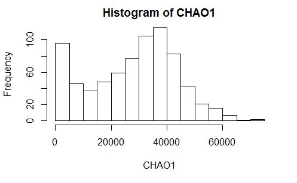

```r
hist(CHAO1)
```

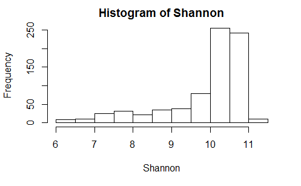

```r
hist(Shannon)
```

3. Some of these look particularly interesting in relation to our response variable (either `CHAO1` or `Shannon`). Produce three boxplots of variables that seem like they may have explanatory power.

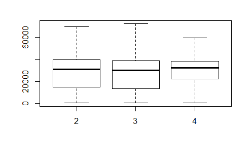

```r
# good / interesting / simple ones:
boxplot(CHAO1 ~ age)
```

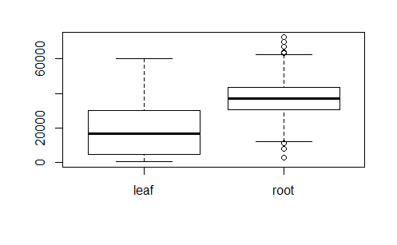

```r
boxplot(CHAO1 ~ habitat)
```

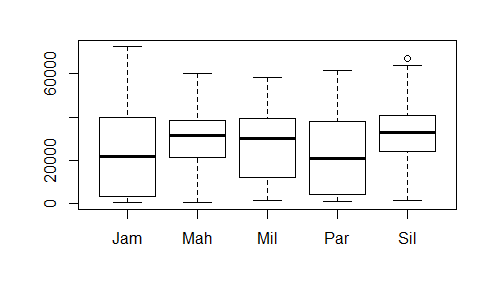

```r
boxplot(CHAO1 ~ site)
```

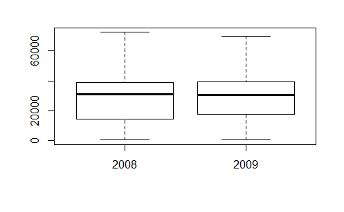

```r
boxplot(CHAO1 ~ planting)
```

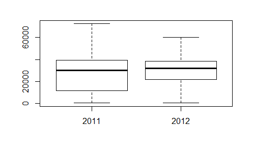

```r
boxplot(CHAO1 ~ sampling)
```

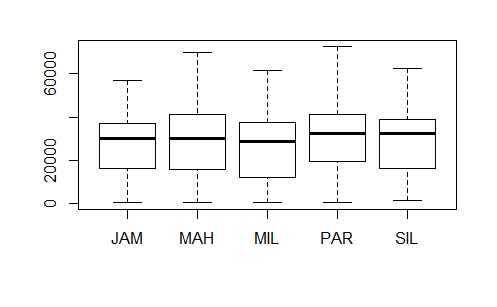

```r
boxplot(CHAO1 ~ geno)
```

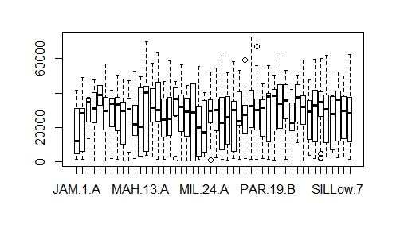

```r
# orrible ones, a lot of levels so maybe notsomuch
boxplot(CHAO1 ~ line1)
```

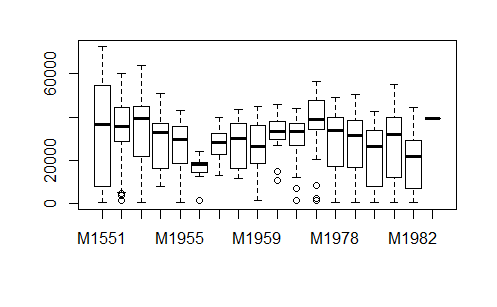

```r
boxplot(CHAO1 ~ block)
```

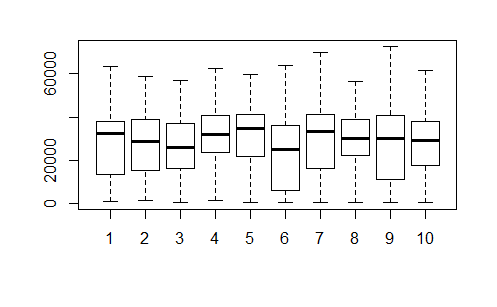

```r
boxplot(CHAO1 ~ miseq_run)
```

4. Now fit a model using these terms. Start with a maximal model, and try to refine it to produce a minimal adequate model, by any means you see fit.

```r
my_model = lm(CHAO1 ~ habitat * sampling * line1)
anova(my_model)
```

```
Analysis of Variance Table

Response: CHAO1
                        Df     Sum Sq    Mean Sq  F value
habitat                  1 6.4797e+10 6.4797e+10 436.9022
sampling                 1 1.3761e+09 1.3761e+09   9.2784
line1                   47 6.5391e+09 1.3913e+08   0.9381
habitat:sampling         1 1.1049e+10 1.1049e+10  74.5000
habitat:line1           47 5.9893e+09 1.2743e+08   0.8592
sampling:line1          16 1.3172e+09 8.2327e+07   0.5551
habitat:sampling:line1   8 9.9782e+08 1.2473e+08   0.8410
Residuals              634 9.4029e+10 1.4831e+08
                          Pr(>F)
habitat                < 2.2e-16 ***
sampling                0.002415 **
line1                   0.592572
habitat:sampling       < 2.2e-16 ***
habitat:line1           0.736259
sampling:line1          0.916795
habitat:sampling:line1  0.566680
Residuals
---
Signif. codes:
0 *** 0.001 ** 0.01 * 0.05 . 0.1   1
```

```r
drop1(my_model,test = "F")
```

```
Single term deletions

Model:
CHAO1 ~ habitat * sampling * line1
                       Df Sum of Sq        RSS   AIC
<none>                              9.4029e+10 14335
habitat:sampling:line1  8 997816895 9.5027e+10 14327
                       F value Pr(>F)
<none>
habitat:sampling:line1   0.841 0.5667
```

```r
# line1 looks useless, drop it
my_model2 = update(my_model, . ~ . - line1)
anova(my_model2)
```

```
Analysis of Variance Table

Response: CHAO1
                        Df     Sum Sq    Mean Sq  F value
habitat                  1 6.4797e+10 6.4797e+10 436.9022
sampling                 1 1.3761e+09 1.3761e+09   9.2784
habitat:sampling         1 1.1285e+10 1.1285e+10  76.0914
habitat:line1           94 1.2292e+10 1.3077e+08   0.8817
sampling:line1          16 1.3172e+09 8.2327e+07   0.5551
habitat:sampling:line1   8 9.9782e+08 1.2473e+08   0.8410
Residuals              634 9.4029e+10 1.4831e+08
                          Pr(>F)
habitat                < 2.2e-16 ***
sampling                0.002415 **
habitat:sampling       < 2.2e-16 ***
habitat:line1           0.774379
sampling:line1          0.916795
habitat:sampling:line1  0.566680
Residuals
---
Signif. codes:
0 *** 0.001 ** 0.01 * 0.05 . 0.1   1
```

```r
# interactions aren't significant, or sensible. lose them
my_model3 = lm(CHAO1 ~ habitat * sampling)
anova(my_model3)
```

```
Analysis of Variance Table

Response: CHAO1
                  Df     Sum Sq    Mean Sq  F value
habitat            1 6.4797e+10 6.4797e+10 448.5382
sampling           1 1.3761e+09 1.3761e+09   9.5255
habitat:sampling   1 1.1285e+10 1.1285e+10  78.1179
Residuals        752 1.0864e+11 1.4446e+08
                    Pr(>F)
habitat          < 2.2e-16 ***
sampling          0.002101 **
habitat:sampling < 2.2e-16 ***
Residuals
---
Signif. codes:
0 *** 0.001 ** 0.01 * 0.05 . 0.1   1
```

```r
drop1(my_model3)
```

```
Single term deletions

Model:
CHAO1 ~ habitat * sampling
                 Df  Sum of Sq        RSS   AIC
<none>                         1.0864e+11 14208
habitat:sampling  1 1.1285e+10 1.1992e+11 14281
```

```r
# looks appropriate - try adding another variable
add1(my_model3,. ~ . + block,test="F")
```

```
Single term additions

Model:
CHAO1 ~ habitat * sampling
       Df  Sum of Sq        RSS   AIC F value    Pr(>F)
<none>               1.0864e+11 14208
block  17 1.7425e+10 9.1211e+10 14110  8.2598 < 2.2e-16

<none>
block  ***
---
Signif. codes:
0 *** 0.001 ** 0.01 * 0.05 . 0.1   1
```

```r
my_model4 = update(my_model3, . ~ . + block)
anova(my_model4)
```

```
Analysis of Variance Table

Response: CHAO1
                  Df     Sum Sq    Mean Sq F value
habitat            1 6.4797e+10 6.4797e+10 522.151
sampling           1 1.3761e+09 1.3761e+09  11.089
block             17 2.4085e+10 1.4168e+09  11.417
habitat:sampling   1 4.6250e+09 4.6250e+09  37.269
Residuals        735 9.1211e+10 1.2410e+08
                    Pr(>F)
habitat          < 2.2e-16 ***
sampling         0.0009118 ***
block            < 2.2e-16 ***
habitat:sampling 1.665e-09 ***
Residuals
---
Signif. codes:
0 *** 0.001 ** 0.01 * 0.05 . 0.1   1
```

```r
# etc...
```

5. Did you forget to check anything? ;) *Inspect residuals/diagnostic plots*

## Model selection by stepwise AIC

So far, so good - but there are a *lot* of possible combinations here. We’ll use an automated model selection function, `step()` to have a go.

5. Use the `step()` function to fit a model describing microbial diversity in terms of tissue (leaf/root), site, age, genotype, year, block, line, and MiSeq run, using forwards search. Start with a simple linear regression of age vs. diversity.

```r
# backwards
backwards_final=step(lm(CHAO1 ~ habitat * sampling * block * site),direction="backward")
```

```
Start:  AIC=13964.62
CHAO1 ~ habitat * sampling * block * site


Step:  AIC=13964.62
CHAO1 ~ habitat + sampling + block + site + habitat:sampling +
    habitat:block + sampling:block + habitat:site + sampling:site +
    block:site + habitat:sampling:block + habitat:sampling:site +
    habitat:block:site + sampling:block:site

                         Df Sum of Sq        RSS   AIC
- habitat:block:site     15 927984422 5.4004e+10 13948
- sampling:block:site     7 410314129 5.3487e+10 13956
- habitat:sampling:block  4  70248006 5.3146e+10 13958
- habitat:sampling:site   2  17991546 5.3094e+10 13961
<none>                                5.3076e+10 13965

Step:  AIC=13947.72
CHAO1 ~ habitat + sampling + block + site + habitat:sampling +
    habitat:block + sampling:block + habitat:site + sampling:site +
    block:site + habitat:sampling:block + habitat:sampling:site +
    sampling:block:site

                         Df  Sum of Sq        RSS   AIC
- sampling:block:site    13 1261365216 5.5266e+10 13939
- habitat:sampling:block  5  272591897 5.4277e+10 13942
- habitat:sampling:site   2   63924277 5.4068e+10 13945
<none>                                 5.4004e+10 13948

Step:  AIC=13939.18
CHAO1 ~ habitat + sampling + block + site + habitat:sampling +
    habitat:block + sampling:block + habitat:site + sampling:site +
    block:site + habitat:sampling:block + habitat:sampling:site

                         Df  Sum of Sq        RSS   AIC
- block:site             53 3529506212 5.8795e+10 13880
- habitat:sampling:block  5  312752041 5.5578e+10 13933
<none>                                 5.5266e+10 13939
- habitat:sampling:site   3  545657803 5.5811e+10 13941

```

[output cut: 14 more lines]

```

                        Df  Sum of Sq        RSS   AIC
- sampling:block        15 1429683241 6.0549e+10 13862
<none>                                5.9119e+10 13874
- habitat:sampling:site  3  899478509 6.0019e+10 13880
- habitat:block         15 3481185477 6.2601e+10 13887

Step:  AIC=13862.2
CHAO1 ~ habitat + sampling + block + site + habitat:sampling +
    habitat:block + habitat:site + sampling:site + habitat:sampling:site

                        Df  Sum of Sq        RSS   AIC
<none>                                6.0549e+10 13862
- habitat:block         16 3471411436 6.4020e+10 13872
- habitat:sampling:site  3 1332654239 6.1882e+10 13873
```

```r
# forwards
forward_final=step(lm(CHAO1 ~ age * habitat),scope=(~age*habitat*block*sampling),direction="forward")
```

```
Start:  AIC=14269.89
CHAO1 ~ age * habitat

           Df  Sum of Sq        RSS   AIC
+ block    17 2.0875e+10 9.7010e+10 14156
+ sampling  1 1.3059e+09 1.1658e+11 14264
<none>                   1.1789e+11 14270

Step:  AIC=14156.55
CHAO1 ~ age + habitat + block + age:habitat

                Df  Sum of Sq        RSS   AIC
+ habitat:block 16 7588696956 8.9421e+10 14127
+ sampling       1 1611284604 9.5399e+10 14146
<none>                        9.7010e+10 14156
+ age:block     16 3464094765 9.3546e+10 14161

Step:  AIC=14126.97
CHAO1 ~ age + habitat + block + age:habitat + habitat:block

            Df  Sum of Sq        RSS   AIC
+ sampling   1 4088775580 8.5332e+10 14094
<none>                    8.9421e+10 14127
+ age:block 16 2040251929 8.7381e+10 14142

Step:  AIC=14093.59
CHAO1 ~ age + habitat + block + sampling + age:habitat + habitat:block

                   Df  Sum of Sq        RSS   AIC
+ block:sampling   15 6212344973 7.9120e+10 14066
+ habitat:sampling  1 2963176807 8.2369e+10 14069
<none>                           8.5332e+10 14094
+ age:sampling      1   35266820 8.5297e+10 14095
+ age:block        16 1986436761 8.3346e+10 14108

Step:  AIC=14066.44
CHAO1 ~ age + habitat + block + sampling + age:habitat + habitat:block +
    block:sampling

                   Df  Sum of Sq        RSS   AIC
+ habitat:sampling  1 1242090386 7.7878e+10 14056
<none>                           7.9120e+10 14066
+ age:sampling      1    9676451 7.9110e+10 14068
+ age:block        16 1178958898 7.7941e+10 14087

Step:  AIC=14056.48
CHAO1 ~ age + habitat + block + sampling + age:habitat + habitat:block +
    block:sampling + habitat:sampling

                         Df  Sum of Sq        RSS   AIC
<none>                                 7.7878e+10 14056
+ age:sampling            1   30616725 7.7847e+10 14058
+ habitat:block:sampling  5  521277697 7.7357e+10 14061
+ age:block              16 1209768501 7.6668e+10 14077
```

6. Write out the full model equation, including fitted terms, for the final model.

```r
anova(my_model,my_model2,my_model3,my_model4,forward_final)
```

```
Analysis of Variance Table

Model 1: CHAO1 ~ habitat * sampling * line1
Model 2: CHAO1 ~ habitat + sampling + habitat:sampling + habitat:line1 +
    sampling:line1 + habitat:sampling:line1
Model 3: CHAO1 ~ habitat * sampling
Model 4: CHAO1 ~ habitat + sampling + block + habitat:sampling
Model 5: CHAO1 ~ age + habitat + block + sampling + age:habitat + habitat:block +
    block:sampling + habitat:sampling
  Res.Df        RSS   Df   Sum of Sq      F    Pr(>F)
1    634 9.4029e+10
2    634 9.4029e+10    0  0.0000e+00
3    752 1.0864e+11 -118 -1.4607e+10 0.8347    0.8878
4    735 9.1211e+10   17  1.7425e+10 6.9112 1.828e-15 ***
5    702 7.7878e+10   33  1.3333e+10 2.7243 1.264e-06 ***
---
Signif. codes:
0 *** 0.001 ** 0.01 * 0.05 . 0.1   1
```

```r
summary(forward_final)
```

```
Call:
lm(formula = CHAO1 ~ age + habitat + block + sampling + age:habitat +
    habitat:block + block:sampling + habitat:sampling)

Residuals:
   Min     1Q Median     3Q    Max
-31669  -6039   -256   6149  37060

Coefficients: (3 not defined because of singularities)
                         Estimate Std. Error t value
(Intercept)                 14346       4136   3.468
age                         -2592       1152  -2.249
habitatroot                 33068       5286   6.256
blockM1554                   8572       4077   2.103
blockM1555                   8224       3807   2.160
blockM1690                  18087       7876   2.296
blockM1955                   8332       3683   2.262
blockM1956                   7123       4739   1.503
blockM1957                  14939       5033   2.968
blockM1958                  12582       5033   2.500
blockM1959                   9427       4125   2.285
blockM1960                  23323       4364   5.345
blockM1961                  19629       4076   4.816
blockM1977                  17798       4174   4.264
blockM1978                   7113       4205   1.691
blockM1979                   2986       3625   0.824
blockM1980                   4762       3076   1.548
blockM1981                   5725       3115   1.838
blockM1982                  -1985       3223  -0.616
blockM1992                 -28004      11664  -2.401
sampling2012                25966       3751   6.923
age:habitatroot              4103       1602   2.562
habitatroot:blockM1554     -18055       4904  -3.682
habitatroot:blockM1555     -15036       4623  -3.253
habitatroot:blockM1690      -2936      12905  -0.228
habitatroot:blockM1955     -26909       4799  -5.608
habitatroot:blockM1956     -36190       9359  -3.867
habitatroot:blockM1957     -54260       8651  -6.272
habitatroot:blockM1958      -8829      12170  -0.725
habitatroot:blockM1959     -35989      11803  -3.049
```

[output cut: 77 more lines]

```
blockM1977:sampling2012  0.032690 *
blockM1978:sampling2012  0.006260 **
blockM1979:sampling2012  0.054482 .
blockM1980:sampling2012  0.003989 **
blockM1981:sampling2012  0.001058 **
blockM1982:sampling2012  0.001879 **
blockM1992:sampling2012        NA
habitatroot:sampling2012 0.000863 ***
---
Signif. codes:
0 *** 0.001 ** 0.01 * 0.05 . 0.1   1

Residual standard error: 10530 on 702 degrees of freedom
Multiple R-squared:  0.5815,    Adjusted R-squared:  0.5499
F-statistic: 18.41 on 53 and 702 DF,  p-value: < 2.2e-16
```

7. How does this compare to the model you produced by heuristic search in (3) above?

```r
anova(my_model4,forward_final,test="F")
```

```
Analysis of Variance Table

Model 1: CHAO1 ~ habitat + sampling + block + habitat:sampling
Model 2: CHAO1 ~ age + habitat + block + sampling + age:habitat + habitat:block +
    block:sampling + habitat:sampling
  Res.Df        RSS Df  Sum of Sq     F    Pr(>F)
1    735 9.1211e+10
2    702 7.7878e+10 33 1.3333e+10 3.642 9.643e-11 ***
---
Signif. codes:
0 *** 0.001 ** 0.01 * 0.05 . 0.1   1
```

8. Now try the same thing, but this time start with a different model (any of your choosing). What do you notice? *The MAM may not be the same*
9. Perform a backwards search (`direction=backward`), starting with a more complex model containing interaction terms (e.g. in `*` combination). What do you notice? *ibid. see above*
10. Finally, perform a bidirectional search, starting with your model from (3) above (`direction=both`). How does this compare to your model?

```r
final_final=step(lm(CHAO1~age*habitat),scope=c(lower=~habitat,upper=~ age* habitat * sampling * block * site),direction="both")
```

```
Start:  AIC=14269.89
CHAO1 ~ age * habitat

              Df  Sum of Sq        RSS   AIC
+ block       17 2.0875e+10 9.7010e+10 14156
+ site         4 1.0886e+10 1.0700e+11 14205
+ sampling     1 1.3059e+09 1.1658e+11 14264
<none>                      1.1789e+11 14270
- age:habitat  1 3.1850e+09 1.2107e+11 14288

Step:  AIC=14156.55
CHAO1 ~ age + habitat + block + age:habitat

                Df  Sum of Sq        RSS   AIC
+ site           4 1.4484e+10 8.2526e+10 14042
+ habitat:block 16 7.5887e+09 8.9421e+10 14127
+ sampling       1 1.6113e+09 9.5399e+10 14146
<none>                        9.7010e+10 14156
- age:habitat    1 2.6619e+08 9.7276e+10 14157
+ age:block     16 3.4641e+09 9.3546e+10 14161
- block         17 2.0875e+10 1.1789e+11 14270

Step:  AIC=14042.31
CHAO1 ~ age + habitat + block + site + age:habitat

                Df  Sum of Sq        RSS   AIC
+ habitat:site   4 1.3328e+10 6.9198e+10 13917
+ habitat:block 16 6.7690e+09 7.5757e+10 14010
+ age:site       4 1.8930e+09 8.0633e+10 14033
- age:habitat    1 8.3840e+06 8.2535e+10 14040
+ block:site    53 1.0958e+10 7.1568e+10 14041
<none>                        8.2526e+10 14042
+ sampling       1 1.0294e+08 8.2423e+10 14043
+ age:block     16 2.4920e+09 8.0034e+10 14051
- site           4 1.4484e+10 9.7010e+10 14156
- block         17 2.4473e+10 1.0700e+11 14205

Step:  AIC=13917.14
CHAO1 ~ age + habitat + block + site + age:habitat + habitat:site

```

[output cut: 100 more lines]

```

Step:  AIC=13852.32
CHAO1 ~ age + habitat + block + site + sampling + age:habitat +
    habitat:site + age:site + habitat:block + site:sampling +
    habitat:sampling + age:habitat:site + habitat:site:sampling

                        Df  Sum of Sq        RSS   AIC
<none>                                5.8357e+10 13852
+ age:sampling           1   18610970 5.8338e+10 13854
- age:habitat:site       3 1149765524 5.9507e+10 13861
- habitat:block         16 3350460211 6.1707e+10 13862
+ sampling:block        15 1266641959 5.7090e+10 13866
- habitat:site:sampling  3 1574580116 5.9931e+10 13866
+ age:block             16  815076344 5.7542e+10 13874
+ block:site            53 3833784674 5.4523e+10 13907
```

```r
anova(forward_final,backwards_final,final_final)
```

```
Analysis of Variance Table

Model 1: CHAO1 ~ age + habitat + block + sampling + age:habitat + habitat:block +
    block:sampling + habitat:sampling
Model 2: CHAO1 ~ habitat + sampling + block + site + habitat:sampling +
    habitat:block + habitat:site + sampling:site + habitat:sampling:site
Model 3: CHAO1 ~ age + habitat + block + site + sampling + age:habitat +
    habitat:site + age:site + habitat:block + site:sampling +
    habitat:sampling + age:habitat:site + habitat:site:sampling
  Res.Df        RSS Df  Sum of Sq      F   Pr(>F)
1    702 7.7878e+10
2    704 6.0549e+10 -2 1.7329e+10
3    695 5.8357e+10  9 2.1922e+09 2.9009 0.002238 **
---
Signif. codes:
0 *** 0.001 ** 0.01 * 0.05 . 0.1   1
```

*ibid.++; and the final final one seems best.*

## Bonus question if you finish early

Hopefully by now, you won’t find it hard to work out which variables are continuous, and which are categorical. Do this now - take a piece of paper and write them out. However… there is something special about `block` and MiSeq run - and something else special about `age` and planting/sampling year. Can you think that they are? *Block, line and one are blocking factors, we may want to treat these differently somehow. Data are pooled potentially. Age, and sample/planting year are time-series/autocorrelated*

## Super-bonus

It’s Friday! Enjoy the weekend, you’ve earnt it.

## Reference

Wagner MR, Lundberg DS, del Rio TG, Tringe SG, Dangl JL, Mitchell-Olds T (2016) Host genotype and age shape the leaf and root microbiomes of a wild perennial plant. *Nature Communications* **7**:12151. https://doi.org/10.1038/ncomms12151